# README slides

## Turn your notebooks into slideshows

Press `Space` to proceed.

You can write a regular Jupyter notebook, with the usual mix of markdown and code cells (keep on pressing `Space`).

In code cells you press `Shift-Enter` as usual to evaluate your code (but for now press `Space` again).

```python
# this is where you press Shift-Enter
import numpy as np
import matplotlib.pyplot as plt
plt.ion()

"Hello world"
```

```
'Hello world'
```

But apart from that, `Space` is your friend!

You're in a browser, so remember that you can always use smaller / larger fonts with keyboard shortcuts like `Alt +` and `Alt -` or similar (it could be `Ctrl` instead of `Alt` depending on the platform you are on).

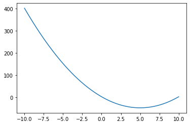

```python
# of course you can show figures

def polynom(x):
    return 2 * x**2 - 20 * x + 2

X = np.linspace(-10, 10)
Y = polynom(X)
plt.plot(X, Y);
```

```python
# and everything works as usual

# an animation to illustrate
# translation by variable change
from ipywidgets import interact, FloatSlider

def parabolic(offset):
    X = np.linspace(-10, 10)
    Y = polynom(X-offset)
    # use same y scale for all offsets
    plt.gca().set_ylim([-100, 500])
    plt.plot(X, Y);

interact(parabolic,
         offset=FloatSlider(min=-10., max=10.,
                           step=0.25));
```

[output not shown]

# The RISE notebook extension

All this is achieved through the RISE notebook extension.

See full documentation at http://rise.readthedocs.io/.

# Thanks to reveal.js

The underlying tool is [reveal.js](https://revealjs.com/), and it supports a lot of cool features.

For example you can organize your show into:

- slides (left to right)
- subslides (top to bottom)
- fragments (stops inside a slide)

You do not need to worry, just press `Space` to proceed along the main line.

For example this is a subslide; observe the cursor in the bottom right corner.

If you press `Shift-Space` - here or anywhere else - you will go backwards, so here it would be up.

# Speaker notes

If you now press `t` you should see a second window open, with a presenter view, that shows *Notes* cells - that won't show up in the main slides.

Next, we'll cover how to tag cells as *Slide*, *SubSlide*, *Fragment* or *Notes*.

# How to create slideshows

### Step 1: enable slideshow cell toolbar

[figure not shown]

### Step 2: add appropriate tag to each cell

From the cell toolbar...

[figure not shown]

or, in command mode, use keyboard shortcuts

- `shift-i` : toggle slide
- `shift-b` : toggle subslide
- `shift-g` : toggle fragment

# CSS

```python
# sample code cell
message = "my look is changed by both rise.css and README.css"
```

# Publishing on binder

In order for a binder-hosted notebook to start in slideshow mode, you need to have the following tag set in the notebook metadata:

```
...
    "rise": {
        "autolaunch": true
    }
    ...
```

You can edit the notebook metadata from the `edit` menu, submenu `edit notebook metadata`.

Note finally that the `rise` key in this json file used to be named `livereveal`. The latter is still honored, but the former takes precedence, and it is recommended to use only `rise` from now on.

# Chalkboard

As an option, you can turn on the *chalkboard* reveal plugin, that manifests itself with 2 extra buttons in the lower left area, that let you add free drawings on your slides.

This option is turned on, in the notebook metadata again, with:

```
...
    "rise": {
      "enable_chalkboard": true
    }
    ...
```